# Exam 1 - Units, Vectors, and Kinematics

**Date:** / /

**Class Number:** PHYS 1061 H002 **Instructor:** Michael Haas

**Name:**

Score: / 42 + Bonus: / 6 = Total: / 42 || Final: % -> [A, B, C, D, F]

Problem #1 (3 points)

How many significant figures are in the number $003.142 $?

1. 2
2. 3
3. 4
4. 5

Problem #2 (3 points)

For general projectile motion, which of the following best describes the horizontal and vertical components of a projectile's acceleration (assume air resistances is negligible)?

1. $a_x = 0$, $a_y = -g$
2. $a_x = -g$, $a_y = 0$
3. $a_x = 0$, $a_y = g$
4. $a_x = g$, $a_y = 0$

Problem #3 (3 points)

A red water balloon is thrown horizontally from the top of a bridge. At the same instant, a yellow water balloon is dropped off the bridge from the same height. What can be said about the time it takes for the balloons to hit the ground (assume air resistances is negligible)?

1. The red balloon will hit the ground first.
2. The yellow balloon will hit the ground first.
3. Both balloons will hit the ground at the same time.
4. It is impossible to determine without more information.

Problem #4 (3 points)

Rose Lavelle kicks a soccer ball at an angle of $32.0 ^\circ$ above the horizontal with a speed of $v_0$. What is the $y$-component of velocity at the top of the ball's trajectory?

1. $v_{y,\mathrm{top}}$ $=$ $—v_0 \sin$ $32.0 ^\circ$
2. $v_{y,\mathrm{top}}$ $=$ $9.81 \frac{\mathrm{m}}{\mathrm{s}}$
3. $v_{y,\mathrm{top}}$ $=$ $0.00 \frac{\mathrm{m}}{\mathrm{s}}$
4. $v_{y,\mathrm{top}}$ $=$ $|v_0|$
5. $v_{y,\mathrm{top}}$ $=$ $v_0 \cos$ $32.0 ^\circ$

Problem #5 (3 points)

The figure shows the velocity versus time graph for a car driving on a straight road. Which of the following best describes the acceleration of the car?

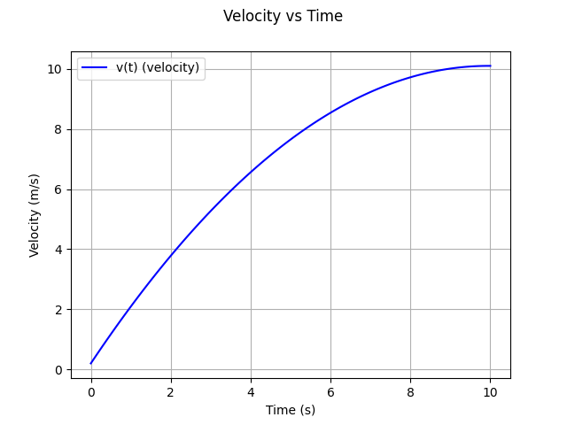

1. The acceleration is positive and increasing.
2. The acceleration is positive and decreasing.
3. The acceleration is negative and increasing.
4. The acceleration is negative and decreasing.

Bonus #6 (3 points)

What is the answer; to the great question of Life, the Universe, and Everything? 42

Problem #7 (3 points)

Quinn accelerates at a rate of $2.45 \frac{\mathrm{blark}}{\mathrm{zoomer}^{2}}$.

Extra information

$1.00 \mathrm{blark}$ $=$ $0.592 \mathrm{yd}$

$1.00 \mathrm{yd}$ $=$ $0.914 \mathrm{m}$

$1.00 \mathrm{zoomer}$ $=$ $1.20 \mathrm{h}$

$1.00 \mathrm{h}$ $=$ $3.60e+03 \mathrm{s}$

Question #1 (3 points)

Determine Quinn's acceleration in $\frac{\mathrm{m}}{\mathrm{s}^{2}}$.

$ 2.45 \frac{\mathrm{blark}}{\mathrm{zoomer}^{2}} \cdot \frac{0.592 \mathrm{yd}}{1.00 \mathrm{blark}} \cdot \frac{0.914 \mathrm{m}}{1.00 \mathrm{yd}} \cdot \frac{1.00 \mathrm{zoomer}}{1.20 \mathrm{h}} \cdot \frac{1.00 \mathrm{zoomer}}{1.20 \mathrm{h}} \cdot \frac{1.00 \mathrm{h}}{3.60e+03 \mathrm{s}} \cdot \frac{1.00 \mathrm{h}}{3.60e+03 \mathrm{s}}= 7.10e-08 \frac{\mathrm{m}}{\mathrm{s}^{2}}$

Problem #8 (6 points)

Alvin Kamara has a mass of $97.1 \mathrm{kg}$ and ran $36.6 \mathrm{m}$, accelerating to a speed of $8.02 \frac{\mathrm{m}}{\mathrm{s}}$.

Question #1 (3 points)

Determine Alvin's acceleration.

$v_{x}^2 = v_{0_x}^2 + 2 a \Delta x$

where $v_{0_x} = 0$

$a=\frac{v_x^2}{2\Delta x}$; $a=\frac{(8.02 \frac{\mathrm{m}}{\mathrm{s}})^2}{2 \cdot 36.6 \mathrm{m}}$

$a=$ $0.879 \frac{\mathrm{m}}{\mathrm{s}^{2}}$

Question #2 (3 points)

Determine Alvin's time in the $36.6 \mathrm{m}$ dash.

$v_x = v_{0_x} + a t$

where $v_{0_x} = 0$

$t = \frac{v_x}{a}$; $t = \frac{8.02 \frac{\mathrm{m}}{\mathrm{s}}}{0.879 \frac{\mathrm{m}}{\mathrm{s}^{2}}}$

$t=$ $9.13 \mathrm{s}$

Problem #9 (6 points)

A person is on top of a building and drops a stone. The stone hits the ground $3.50 \mathrm{s}$ later.

Question #1 (3 points)

Determine the velocity of the stone when it hits the ground.

$v_y=v_0+at$

where $v_0=0$; $a=-g=$ $-9.81 \frac{\mathrm{m}}{\mathrm{s}^{2}}$; $v_y=$ $-9.81 \frac{\mathrm{m}}{\mathrm{s}^{2}}$ $3.50 \mathrm{s}$

$v_y=$ $-34.3 \frac{\mathrm{m}}{\mathrm{s}}$ .

Question #2 (3 points)

Determine the height of the building.

$y=y_0+v_{0_y}t+\frac12at^2$

where $y_0=0$; $v_{0_y}=0$; $a=$ $-9.81 \frac{\mathrm{m}}{\mathrm{s}^{2}}$

$y=$ $-60.1 \mathrm{m}$

$h=|y|=$ $60.1 \mathrm{m}$.

Bonus #10 (3 points)

Pikachu uses Thunderbolt, discharging a current of $15.0 \mathrm{A}$ through a $20.0 \mathrm{Ω}$ resistor. How much electrical power does Pikachu generate? Use the formula $P = I^2 R$. $P=$ $4.50e+03 \mathrm{W}$

Problem #11 (12 points)

Joseph Fourier tosses a stone of mass of $0.430 \mathrm{kg}$ with a speed of $26.8 \frac{\mathrm{m}}{\mathrm{s}}$ at an angle of $18.3 ^\circ$ degrees above the horizontal from a height of $1.20 \mathrm{m}$ towards a wall that is $30.5 \mathrm{m}$ away.

Question #1 (3 points)

Create and draw a well labeled diagram of the situation. Be sure to include all known and unknown quantities.

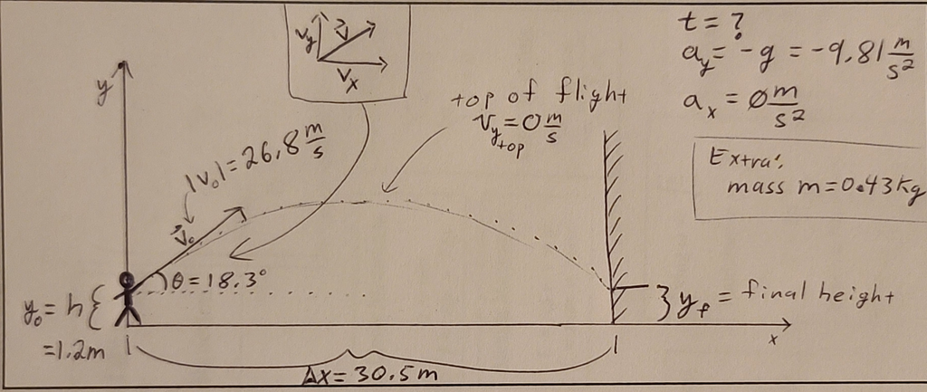

Question #2 (3 points)

Resolve the initial velocity into $x$ and $y$ components.

$v_{0_x} = v_0 \cos(\theta_i)$; $v_{0_y} = v_0 \sin(\theta_i)$

$v_{0_x} = 26.8 \frac{\mathrm{m}}{\mathrm{s}} \cos(18.3 ^\circ)$; $v_{0_y} = 26.8 \frac{\mathrm{m}}{\mathrm{s}} \sin(18.3 ^\circ)$

$v_{0_x} = 25.4 \frac{\mathrm{m}}{\mathrm{s}}$; $v_{0_y} = 8.41 \frac{\mathrm{m}}{\mathrm{s}}$

Question #3 (3 points)

Determine the time ($t$) taken for the stone to hit the wall.

$x_f = x_0 + v_{0_x} t$

where $x_0 = 0$; $v_{0_x} = 25.4 \frac{\mathrm{m}}{\mathrm{s}}$

$t = \frac{x_f}{v_{0_x}}$; $t = \frac{30.5 \mathrm{m}}{25.4 \frac{\mathrm{m}}{\mathrm{s}}}$

$t = 1.20 \mathrm{s}$

Question #4 (3 points)

Determine the height of the stone when it hits the wall.

$y = y_0 + v_{0_y} t + \frac{1}{2} a t^2$

where $y_0 = 1.20 \mathrm{m}$; $v_{0_y} = 8.41 \frac{\mathrm{m}}{\mathrm{s}}$; $a = -g = -9.81 \frac{\mathrm{m}}{\mathrm{s}^{2}}$; $t=1.20 \mathrm{s}$

$y = 4.24 \mathrm{m}$